# Final-6

Mike Lehman

December 6, 2016

## Introduction

The goal of this assessment is to predict the price of used automobiles based on a variety of input data predictors. The vehicle data we will be using comes from European automobile sales. The features in the data set include: the price of the vehcile in Euros, the age of the vehicle in months, the accumulated kilometers on the odometer, and the vehicle weight, horsepower, and other aesthetic characteristics such as color.

In order to complete our task of predicting the vehicle price, we will need to first assess the different machine learning models we have at our disposal. Because the majority of the features are numeric, and the feature we are predicitng is numeric and continuous, we can refine and shorten our list of options.

For this assessment we will apply both a standard linear regression model, and a regression tree to compare and contrast for performance metrics. Before going any further, we will load the data set into R and perform some exploratory analysis to see if our model choices are wise or if we should reassess our options.

## Cars Data

We will begin by loading the used car data into R and examining the features.

```r
cars <- read.csv("ToyotaCorolla.csv")
str(cars)
```

```
## 'data.frame':    1436 obs. of  10 variables:
##  $ Price    : int  13500 13750 13950 14950 13750 12950 16900 18600 21500 12950 ...
##  $ Age      : int  23 23 24 26 30 32 27 30 27 23 ...
##  $ KM       : int  46986 72937 41711 48000 38500 61000 94612 75889 19700 71138 ...
##  $ FuelType : Factor w/ 3 levels "CNG","Diesel",..: 2 2 2 2 2 2 2 2 3 2 ...
##  $ HP       : int  90 90 90 90 90 90 90 90 192 69 ...
##  $ MetColor : int  1 1 1 0 0 0 1 1 0 0 ...
##  $ Automatic: int  0 0 0 0 0 0 0 0 0 0 ...
##  $ CC       : int  2000 2000 2000 2000 2000 2000 2000 2000 1800 1900 ...
##  $ Doors    : int  3 3 3 3 3 3 3 3 3 3 ...
##  $ Weight   : int  1165 1165 1165 1165 1170 1170 1245 1245 1185 1105 ...
```

All but the fuel type feature import as integer data types. Before going any further, there are a few issues that need to be addressed. The MetColor and Automatic features appear to be coded as categorical variables. For MetColor, a value of 1 is equal to yes, with 0 being no. The Automatic feature is the same.

We can recode these variables as factors before going any further:

```r
cars$MetColor <- factor(cars$MetColor, levels = c(0,1), labels = c("no", "yes"))
cars$Automatic <- factor(cars$Automatic, levels = c(0,1), labels = c("no", "yes"))
str(cars)
```

```
## 'data.frame':    1436 obs. of  10 variables:
##  $ Price    : int  13500 13750 13950 14950 13750 12950 16900 18600 21500 12950 ...
##  $ Age      : int  23 23 24 26 30 32 27 30 27 23 ...
##  $ KM       : int  46986 72937 41711 48000 38500 61000 94612 75889 19700 71138 ...
##  $ FuelType : Factor w/ 3 levels "CNG","Diesel",..: 2 2 2 2 2 2 2 2 3 2 ...
##  $ HP       : int  90 90 90 90 90 90 90 90 192 69 ...
##  $ MetColor : Factor w/ 2 levels "no","yes": 2 2 2 1 1 1 2 2 1 1 ...
##  $ Automatic: Factor w/ 2 levels "no","yes": 1 1 1 1 1 1 1 1 1 1 ...
##  $ CC       : int  2000 2000 2000 2000 2000 2000 2000 2000 1800 1900 ...
##  $ Doors    : int  3 3 3 3 3 3 3 3 3 3 ...
##  $ Weight   : int  1165 1165 1165 1165 1170 1170 1245 1245 1185 1105 ...
```

Out of our 10 features, three are now factors. Since we are dealing with used vehicle data, and our goal is to predict price, it makes sense to examine some the correlations between the inuitively obvious features. Used vehicle price would logically be highly dependent on age and odometer (KM) reading. It stands to reason that the number of doors and the horsepower would have some correlation to price as well.

We can plot these relationships visually using the psych library to generate a scatterplot matrix:

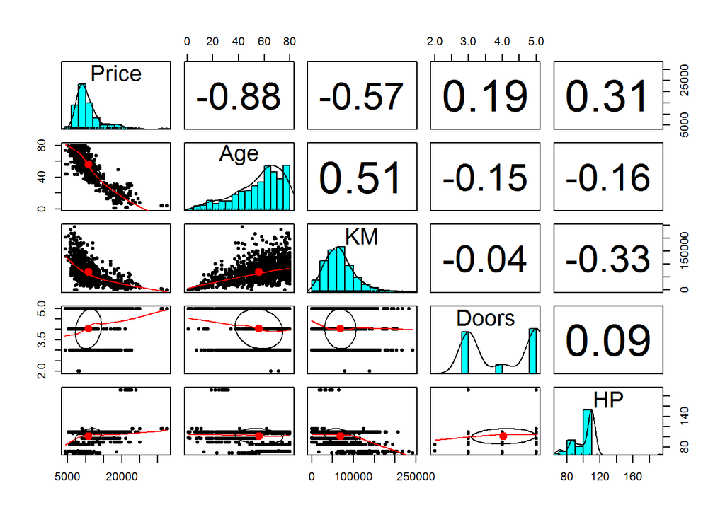

```r
pairs.panels(cars[c("Price", "Age", "KM", "Doors", "HP")])
```

There seems to be a strong negative linear correlations between price as it relates to age and kilometers as seen in the plots in the first column, rows two and three. As age and km increase, price goes down.

Sinc there are some strong linear correlations between a number of the predictor features as they relate to our target feature, we can move forward with fitting a linear regression model with some degree of confidence that it will be successful.

## Linear Regression

Before building our model we will subset our data by creating randomized train and test sets using a traditional 80/20 split for train and test:

```r
set.seed(123)
train_sample <- sample(1436, 1148)
train <- cars[train_sample, ]
test  <- cars[-train_sample, ]
```

Lastly, before fitting our linear regression model, we will make use of the caret library to set a control object with additional parameters for resampling. For our assessment we will use a standard 10-fold cross-validation so that our model will fit on the training data and iterate over validation subsets before we make any predictions on the test data.

```r
ctrl <- trainControl(method = "cv", number = 10)
```

Now that we have our data sets and control parameters, we can fit our linear model. For our model, we will pass all the features as predictors for the target feature, price:

```r
model.cars <- train(Price ~., data = train, method = "lm", trControl = ctrl)
summary(model.cars)
```

```
##
## Call:
## lm(formula = .outcome ~ ., data = dat)
##
## Residuals:
##     Min      1Q  Median      3Q     Max
## -9137.8  -752.3     6.8   767.5  6430.4
##
## Coefficients:
##                  Estimate Std. Error t value Pr(>|t|)
## (Intercept)    -1.085e+03  1.425e+03  -0.762  0.44640
## Age            -1.217e+02  2.953e+00 -41.224  < 2e-16 ***
## KM             -1.625e-02  1.465e-03 -11.094  < 2e-16 ***
## FuelTypeDiesel  3.944e+03  5.717e+02   6.899 8.68e-12 ***
## FuelTypePetrol  1.015e+03  3.489e+02   2.910  0.00368 **
## HP              6.768e+01  6.566e+00  10.307  < 2e-16 ***
## MetColoryes     7.427e+01  8.486e+01   0.875  0.38164
## Automaticyes    3.961e+02  1.711e+02   2.315  0.02076 *
## CC             -4.561e+00  6.188e-01  -7.372 3.23e-13 ***
## Doors           4.149e+01  4.595e+01   0.903  0.36671
## Weight          1.721e+01  1.314e+00  13.096  < 2e-16 ***
## ---
## Signif. codes:  0 '***' 0.001 '**' 0.01 '*' 0.05 '.' 0.1 ' ' 1
##
## Residual standard error: 1335 on 1137 degrees of freedom
## Multiple R-squared:  0.8662, Adjusted R-squared:  0.865
## F-statistic: 735.8 on 10 and 1137 DF,  p-value: < 2.2e-16
```

The summary output of our model provides great details about how our model performed when predicting the price values for the train data set. Residuals are the differences between the predicted and actual values, are lower value is best, and will be relative to the range of the target feature.

Our multiple r-squared and adjusted r-squared values show that our model performed quite well. R-squared refers to the variation explained by the model over the total variation in predicted versus actual values. R-squared values fall between 0% and 100% with a higher value indicating a better fit. The adjusted R-squared is an R-squared value that has been adjusted for the number of predictors in the model and is in general a more accurate reflection of goodness of fit.

Our model explained a great deal of the variation and is therefore a strong candidate for predictive accuracy.

Let’s run a prediction of our model against the test data:

```r
model.prediction <- predict(model.cars, test)
```

The predict function will apply our model to the test data and attempt to predict the price feature based on what it has learned from the train data. To asess our model’s accuracy, we can pass the model’s predicted values to R’s native cor() function as well as the actual test data prices to find the degree of correlation:

```r
cor(model.prediction, test$Price)
```

```
## [1] 0.9401281
```

Correlation between predicted and actual values fill fall between 0 and 1, with a higher value indicating better fit. This values essentially is how close the predicted values are to the actual values.

Our correlation metric of 0.94 indicates very good performance. To further assess accuracy, we can calculate the Mean Absolute Error for our model’s predictions. MAE is exactly as the name implies, the average difference of actual versus predicted values. A low MAE indicates better performance.

To calculate MAE, we will create a custom functions that accepts two vectors, then pass our predicted and actual values into the function:

```r
MAE <- function(actual, predicted) {
  mean(abs(actual - predicted))
}

MAE(test$Price, model.prediction)
```

```
## [1] 895.4666
```

Our MAE score of 895.4666 indicates that, on average the model is only about that many units off from predicting the actual price. Given that Price values range from 4350-32500 this is quite an acceptable average error.

Since our model has performed quite well with 10-fold cross-validation for selective sampling, we can be reasonably assured that this model would perform well with additional unseen data, and that the features (at least most of them) have a linear strong correlation with price.

## Regression Trees

To continue our exploration of the cars data set, we will also build a regression tree model to see if we can exceed, or at least match, or standard linear regression model.

Decision trees are a family of highly extensible machine learning models which can be used for both multivariate classification analyses as well as for the prediction of continuous, numeric outcome variables. Regression trees are a subset of decision trees that can make numeric predictions by averaging the values of features when performing splits. In typical classification trees, those decision tree models split based on the distribution of categorical data. Despite the name, regression trees do not apply linear regression methods, but instead use the average feature values as mentioned for feature splitting.

Since we have already preprocessed and subset our data, we can begin with the model building phase. For our regression tree model we will again use the caret package and specify that “rpart” for the method. Rpart is a library for building regression trees. We can also reuse our control object to use 10-fold cross-validation for sampling:

```r
model.tree.cars <- train(Price ~., data = train, method = "rpart", trControl = ctrl)
model.tree.cars
```

```
## CART
##
## 1148 samples
##    9 predictor
##
## No pre-processing
## Resampling: Cross-Validated (10 fold)
## Summary of sample sizes: 1032, 1035, 1032, 1032, 1034, 1033, ...
## Resampling results across tuning parameters:
##
##   cp          RMSE      Rsquared
##   0.03049145  1672.582  0.7925365
##   0.11589206  1936.969  0.7082553
##   0.66061441  3232.617  0.5749866
##
## RMSE was used to select the optimal model using  the smallest value.
## The final value used for the model was cp = 0.03049145.
```

The results of outputting our model show that the caret package fit three different models and choose the best model based on root mean squared error (RMSE), but it also shows us the compexity parameter and r-squared values for each model.

The r-squared value is not as good as even our linear model’s adjusted r-squared, but let’s run a prediction and see how the model performs:

```r
p.rpart <- predict(model.tree.cars, test)
cor(p.rpart, test$Price)
```

```
## [1] 0.8634687
```

```r
MAE(p.rpart, test$Price)
```

```
## [1] 1296.304
```

Both the correlation and MAE values are worse than our linear model. We can tune the regression tree model further to see if we can improve performance.

We’ll also specify that r-squared should be used to select the optimal model using the metric parameter:

```r
# complexity parameter
grid <- expand.grid(.cp=seq(0.005, 0.05, 0.025))
model.tree.cars <- train(Price ~., data = train, method = "rpart", metric = "Rsquared", trControl = ctrl, tuneGrid = grid)
model.tree.cars
```

```
## CART
##
## 1148 samples
##    9 predictor
##
## No pre-processing
## Resampling: Cross-Validated (10 fold)
## Summary of sample sizes: 1034, 1032, 1033, 1032, 1033, 1033, ...
## Resampling results across tuning parameters:
##
##   cp     RMSE      Rsquared
##   0.005  1442.332  0.8442863
##   0.030  1762.970  0.7684090
##
## Rsquared was used to select the optimal model using  the largest value.
## The final value used for the model was cp = 0.005.
```

Based on the output, a complexity parameter of 0.005 was chosen for the final model.

We can see from the r-squared and RMSE values that our model improved a bit, but still fell short of our linear model against the train data. Let’s run a prediction against the test data to get final numbers:

```r
p.rpart <- predict(model.tree.cars, test)
cor(p.rpart, test$Price)
```

```
## [1] 0.9279017
```

```r
MAE(p.rpart, test$Price)
```

```
## [1] 1020.577
```

For a final pass at matching our linear model, we will fit a Random Forest model.

Random forests are an ensemble learning technique for decision tree models that combine bootstrap aggregating with random feature selection. Random forest implementations build a number of decision trees through random feature selection, then take a vote that is the mode of the predicted classes for classification tasks. Random forests can also be used in regression analysis where the mean prediction is used.

```r
rf <- randomForest(Price ~ ., data = train, ntree = 20)
rf.p <- predict(rf, test)

cor(rf.p, test$Price)
```

```
## [1] 0.9566052
```

```r
MAE(rf.p, test$Price)
```

```
## [1] 831.3867
```

Without any additional performance tuning or parameterization, a Random Forest Model with a total of 20 trees built, exceeded our linear model and our regression trees.

In general, Random forest models can better capture non-linear relationships. Referring back to the summary of our linear model, several of the predictor features did not have significant p values. This means that those features did not have a linear relationship to the target feature, price. Our Random Forest model, because it generates a number of trees and applies random feature selection, was likely able to capture some of those non-linearities, particularly our factor variables.

## Conclusion

Using both linear regression models and regression trees, we were able to predict used vehicle sale price at a fairly accurate level. Further testing on unseen data would need to be performed with each type of model to rule out overfitting, bias, and variance.

Even though our Random Forest Model produced the best results, it is important to note that RF model are quite computationally expensive. If we were facing a much larger data set, like those in the real-world, we would probably start to see performance hits in terms of how fast and efficient an RF model would be in predicting prices.

Despite the fact that our linear model slightly under-performed against the RF, linear models in general are much faster and more computationally efficient to build. Therefore, a linear regression model would probably be the best possible solution for this problem, given the strong linear relationships between several input features and the price of a used vehicle.

R Source